# 量子光学 · 第五讲：Bell不等式

## Bell不等式：量子关联超出了怎样的经典解释？

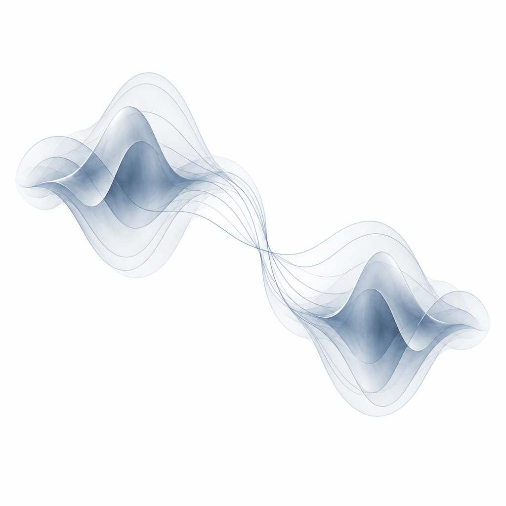

量子光学

第五讲

Bell不等式：量子关联超出了怎样的经典解释？

李梓民  
中南大学物理学院  
zimin.li@csu.edu.cn

zimin.li/quantum-optics/

## 本讲导读

1. 01

### EPR与经典关联

   •从 Bell 态的完全关联出发，追问量子态是否完备。

   •经典答案卡也能产生这种关联，需要进一步检验。
2. 02

### CHSH：经典策略的界限

   •用 CHSH 游戏，找出经典策略的胜率上限。

   •固定答案与随机换卡都受此限制，即贝尔不等式的游戏形式。
3. 03

### 偏振测量：寻找量子策略

   •保留游戏规则，改用纠缠光子的偏振测量结果作答。

   •合适的测量方向能使理论胜率超出经典上限。
4. 04

### 实验检验与物理结论

   •用探测计数检验 CHSH 不等式，核查关键实验条件。

   •在相应前提下，实验排除了局域隐变量模型。

## 目录：EPR与经典关联

目录

CONTENTS

从 Bell 态的确定预测出发：这种关联是否需要预先写好的答案？

## 同测Z、同测X：Bell态都给出相同结果

### 双方都测 Z

$$|\Phi^+\rangle=\frac{|00\rangle+|11\rangle}{\sqrt2}$$

| 结果 | 概率 |
| --- | --- |
| 00 | 1/2 |
| 11 | 1/2 |

### 双方都测 X

$$|\Phi^+\rangle=\frac{|++\rangle+|--\rangle}{\sqrt2}$$

| 结果 | 概率 |
| --- | --- |
| ++ | 1/2 |
| −− | 1/2 |

同测 Z 或同测 X 时，双方结果完全相关；Alice 可由自己的结果确定预测 Bob 的结果。

## EPR：Bob的测量结果早就确定了吗？

1935年，EPR追问：量子态是否写出了系统的全部性质？

### 双方同测Z

Alice看到0 → Bob测Z一定得到0。

Alice看到1 → Bob测Z一定得到1。

### 局域性假设

Alice在远处的测量，不改变Bob原有的物理性质。

### EPR的判据

不扰动Bob就能确定预测他的测量结果，EPR就认为Bob原先已有相应的确定性质（物理实在要素）。

[figure not shown]

EPR因此认为：Bob测Z的结果在Alice测量前，就应已经确定。

[Einstein、Podolsky、Rosen，1935；原论文讨论位置与动量，本讲采用Bohm式两比特重述。](https://doi.org/10.1103/PhysRev.47.777)

## EPR认为量子态还缺少信息

Alice也可以选择测X；知道自己的结果后，同样能预测Bob同测X的结果。

远方选Z或选X都不改变Bob原有的性质。

EPR沿用刚才的判据，认为Bob测Z、测X的结果都应预先确定。

### 若Z结果已经确定

$|0\rangle$或$|1\rangle$

这两个态沿X测量，正、负结果各半。

### 量子态描述的限制

没有一个单比特态能让Z、X两种测量都给出确定结果。

EPR因此提出：现有量子态描述可能还缺少信息。

## Bohr的回应：两种预测来自不同测量安排

Bohr把每次确定预测联系到实际选定的测量安排；是否由此认定两个值都已存在，正是双方的分歧。

接下来用同一项任务比较：预写答案与量子测量，会给出怎样的不同预测？

[Niels Bohr，1935，对EPR论文的回应。](https://doi.org/10.1103/PhysRev.48.696)

## 经典共享信息也能制造完全关联

每轮等概率选0或1，给两人各一盒，装相同数字；重复很多轮。

单独看：每人看到0、1的概率各半。

放在一起：配对数字总是相同。

完全相关本身，还不足以证明存在量子纠缠。

## 第四讲区分了Bell态与00/11随机混合

同测Z时，两者都完全相关；第四讲再让双方同测X：

### Bell态

$$|\Phi^+\rangle=\frac{|00\rangle+|11\rangle}{\sqrt2}$$

两个结果总是相同。

### 00、11各占一半的混合

每轮选00或11，再让双方测X。

同答、异答各占一半。

思考

能否换一种经典办法，连同测X的统计也能模仿？

试给两人相同的卡片，分别预写选择Z、X时的答案。

## 四种答案卡能模仿同测Z、X的统计

用统一标签：Z的0、1分别记为+1、−1；X的+、−也分别记为+1、−1。

| 卡片 | 测Z回答 | 测X回答 |
| --- | --- | --- |
| ① | +1 | +1 |
| ② | +1 | −1 |
| ③ | −1 | +1 |
| ④ | −1 | −1 |

每轮等概率选一种卡片，给两人各一张，内容相同。

各自只按本地方向读卡，分开后不交换方向与结果。

卡片信息称为隐变量$\lambda$；这种解释称为局域隐变量模型。

同测Z或同测X时，两人总同答，各自正负各半；接下来检验更多测量方向。

## 目录：CHSH：经典策略的界限

目录

CONTENTS

同基完全关联尚不能区分解释：换一套共同任务，寻找卡片做不到的要求。

## Bell把解释之争变成可检验的限制

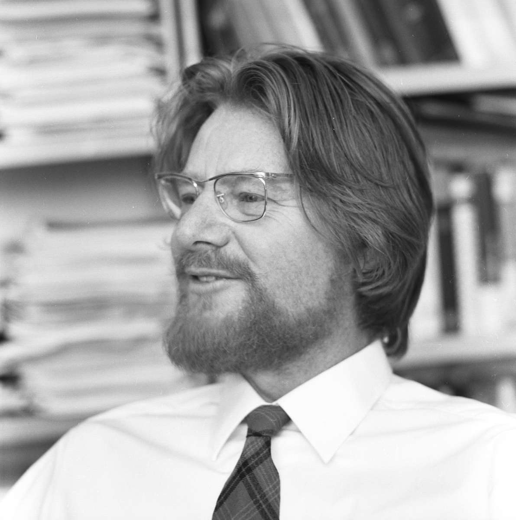

约翰·贝尔  
John Stewart Bell  
1964年：Bell定理

### 1964：Bell

局域隐藏信息

必须服从

一类关联限制

### 1969：CHSH

Clauser、Horne、Shimony、Holt

给出贝尔不等式的CHSH形式。

用游戏给答案卡计分：先找预写答案的最高分，再让纠缠测量按同一规则比赛。

[Bell，1964](https://doi.org/10.1103/PhysicsPhysiqueFizika.1.195)；[CHSH，1969](https://doi.org/10.1103/PhysRevLett.23.880)；照片：Store norske leksikon。

## CHSH规则：前三组同答，最后一组异答

### 游戏规则

Alice收到题号$x\in\{0,1\}$，回答$a\in\{0,1\}$。

Bob收到题号$y\in\{0,1\}$，回答$b\in\{0,1\}$。

每人只看自己的问题；分开后不通信。

| 问题组合 | 获胜条件 |
| --- | --- |
| 00 | $a=b$ |
| 01 | $a=b$ |
| 10 | $a=b$ |
| 11 | $a\ne b$ |

四类问题等概率；主持人每轮出题与双方事先共享的信息独立。

双方可事先商量，也可共享随机信息。

## 经典策略：为每个问题预写答案

四个答案都可自由填写；出题后，各自只读自己所收问题对应的答案。

### Alice

| 收到的问题 | 预写答案 |
| --- | --- |
| 0 | $a_0$ |
| 1 | $a_1$ |

### Bob

| 收到的问题 | 预写答案 |
| --- | --- |
| 0 | $b_0$ |
| 1 | $b_1$ |

思考

四个预写答案各填0或1，四组问题最多能赢几组？

若只把Bob的$b_0$从0改成1，哪些问题组合的回答会改变？

## 经典挑战：四组问题能否全胜？

[interactive chart not shown]

## 经典策略为何不能四组全胜？

四组全胜，要求同一套固定答案同时满足：

| 问题组合 | 获胜规则 | 预写答案须满足 |
| --- | --- | --- |
| 00 | 同答 | $a_0=b_0$ |
| 01 | 同答 | $a_0=b_1$ |
| 10 | 同答 | $a_1=b_0$ |
| 11 | 异答 | $a_1\ne b_1$ |

$a_0$

$b_0$

$b_1$

$a_1$

$=$

$=$

$=$

$\ne$

$$a_1=b_0=a_0=b_1$$

前三个等式推出$a_1=b_1$，与第四个要求矛盾。

固定策略最高胜率为75%；双方始终答0，就能赢前三组、输11组。

## 随机更换答案卡，平均胜率仍不超过75%

上一页已证明：每套固定答案的胜率都不超过75%。规则还允许每轮随机换卡，下面计算这种策略的平均胜率。

### 每套固定答案卡

第$k$套的胜率

$p_k\le75\%$

### 每轮随机选一套

选第$k$套的概率为$q_k$

出题与选卡独立

### 总体理论胜率

按选卡概率加权平均

$\sum_kq_k=1$

$$P_{\mathrm{win}}=\sum_kq_kp_k\le\sum_kq_k\frac34=\frac34$$

四类问题等概率时，固定策略及其随机混合的理论胜率都不超过75%。

## 目录：偏振测量：寻找量子策略

目录

CONTENTS

保留出题和计分规则：共享Bell态并选择测量方向，能否超过经典75%？

## 经典与量子策略遵守同一套游戏规则

现在把答案卡换成纠缠光子的测量，出题、合作与计分规则保持相同。

| 项目 | 两种策略共同遵守的规则 |
| --- | --- |
| 题号与答案 | Alice收到题号$x$，Bob收到$y$；题号和各自答案都取0或1。 |
| 怎样出题 | 00、01、10、11等概率；提问与双方事先共享的信息独立。 |
| 怎样合作 | 赛前可以商量；收到题后各看自己的题，交答案前不通信。 |
| 怎样计分 | 00、01、10：两人答案相同获胜；11：两人答案不同获胜。 |

按这套规则，比较预写答案与纠缠测量各自能达到的理论胜率。

## 经典预写答案，量子预选测量方向

$|H\rangle,|V\rangle$分别对应$|0\rangle,|1\rangle$；每轮两人各拿同一对中的一个光子。

$$|\Phi^+\rangle=\frac{|HH\rangle+|VV\rangle}{\sqrt2}$$

| 步骤 | 经典：预写答案 | 量子：预选方向 |
| --- | --- | --- |
| 事先约定 | Alice：$a_0,a_1$ Bob：$b_0,b_1$ | Alice：$\alpha_0,\alpha_1$ Bob：$\beta_0,\beta_1$ |
| 收到题号$x,y$ | Alice读$a_x$ Bob读$b_y$ | Alice沿$\alpha_x$测量 Bob沿$\beta_y$测量 |
| 交出答案 | 交出读到的0或1 | 测得+1答0；测得−1答1 |

例如01组：Alice沿$\alpha_0$测量，Bob沿$\beta_1$测量；两人都测得+1，就都答0，按“同答”规则获胜。

## 已知Alice的测量结果，确定Bob的偏振态

偏振分析器把两种正交偏振分到两路，由两只探测器记录为+1、−1。先固定Alice测H/V，计算同答概率。

$$|\Phi^+\rangle=\frac{|HH\rangle+|VV\rangle}{\sqrt2}$$

根据已知的Alice结果描述Bob，得到的状态称为Bob的条件态。

## 分别计算两种同答结果的概率，再相加

Bob检测的两个偏振方向互相正交；+1结果对应的方向与H夹角为$\beta$。

$P_{++}$、$P_{--}$表示联合概率；下标依次为Alice、Bob的测量结果。

### Alice：+（H）

占一半

Bob为H（虚线）

同答要求Bob测得+1结果（实线）

此时同答概率：$\cos^2\beta$

$$P_{++}=\tfrac12\times\cos^2\beta$$

### Alice：−（V）

占一半

Bob为V（虚线）

同答要求Bob测得−1结果（实线）

此时同答概率：$\cos^2\beta$

$$P_{--}=\tfrac12\times\cos^2\beta$$

$$P_{\mathrm{same}}=P_{++}+P_{--}=\cos^2\beta$$

## 把H/V测量基整体转过α

H为0°，朝V转动为正。  
两种测量偏振互相正交。

把H/V基整体转过$\alpha$：

$$|\alpha\rangle=\cos\alpha|H\rangle+\sin\alpha|V\rangle$$

$$|\alpha_\perp\rangle=-\sin\alpha|H\rangle+\cos\alpha|V\rangle$$

$|\alpha\rangle$对应+1结果，$|\alpha_\perp\rangle$对应−1结果。

本讲用实际偏振角；对应Bloch球上转过的角度是它的两倍。

## Alice改变测量方向，两种结果仍各占一半

同一个Bell态也可写在双方相同的线偏振基中：

$$|\Phi^+\rangle=\frac{|\alpha\rangle_A|\alpha\rangle_B+|\alpha_\perp\rangle_A|\alpha_\perp\rangle_B}{\sqrt2}$$

### +1结果（答0）：占一半

已知这个结果，Bob对应$|\alpha\rangle$。

### −1结果（答1）：占一半

已知这个结果，Bob对应$|\alpha_\perp\rangle$。

用$|\alpha\rangle$代替H、$|\alpha_\perp\rangle$代替V，沿用刚才的两分支计算。

↓ 查看换基验证

## 换基验证：Bell态为何保持这两个分支？

沿用$|\alpha\rangle=c|H\rangle+s|V\rangle$、$|\alpha_\perp\rangle=-s|H\rangle+c|V\rangle$，其中$c=\cos\alpha,s=\sin\alpha$。

$$\begin{aligned}|\alpha\alpha\rangle&=c^2|HH\rangle+cs|HV\rangle+cs|VH\rangle+s^2|VV\rangle,\\|\alpha_\perp\alpha_\perp\rangle&=s^2|HH\rangle-cs|HV\rangle-cs|VH\rangle+c^2|VV\rangle.\end{aligned}$$

$$\frac{|\alpha\alpha\rangle+|\alpha_\perp\alpha_\perp\rangle}{\sqrt2}=\frac{|HH\rangle+|VV\rangle}{\sqrt2}$$

↑ 返回两分支主页面

## 两人都转动，同答概率取决于方向差

Alice方向为$\alpha$；Bob的+1、−1结果对应的偏振态为$|\beta\rangle$、$|\beta_\perp\rangle$，由前页的定义把α换成β得到。

### 同答：两人都测得+1

从$\alpha$投影到$\beta$，夹角$\alpha-\beta$。

$$|\langle\beta|\alpha\rangle|^2=\cos^2(\alpha-\beta)$$

### 同答：两人都测得−1

这两个偏振态的方向相差$\alpha-\beta$。

$$|\langle\beta_\perp|\alpha_\perp\rangle|^2=\cos^2(\alpha-\beta)$$

两支仍各占一半，沿用刚才的加权相加：

$$P_{\mathrm{same}}=\tfrac12\cos^2(\alpha-\beta)+\tfrac12\cos^2(\alpha-\beta)$$

$$P_{\mathrm{same}}=\cos^2(\alpha-\beta),\qquad P_{\mathrm{diff}}=\sin^2(\alpha-\beta)$$

## 互动：改变测量方向，比较胜率

[interactive chart not shown]

## 选定四个方向，分别计算四组题的胜率

沿用同一Bell态与游戏规则，选取下面四个测量方向：

$$\alpha_0=0^\circ,\quad\alpha_1=45^\circ$$

$$\beta_0=22.5^\circ,\quad\beta_1=-22.5^\circ$$

00、01、10组的夹角为22.5°，要求同答；11组夹角为67.5°，要求异答。

## 量子胜率约85.4%，超过经典上限75%

代入刚才的四个方向：同答用$\cos^2(\alpha-\beta)$，异答用$\sin^2(\alpha-\beta)$。

| 问题组合 | 方向夹角 | 获胜条件 | 获胜概率 |
| --- | --- | --- | --- |
| 00、01、10 | 22.5° | 同答 | $\cos^2 22.5^\circ$ |
| 11 | 67.5° | 异答 | $\sin^2 67.5^\circ$ |

$$\sin^2 67.5^\circ=\cos^2 22.5^\circ$$

$$P_{\mathrm{win}}=\frac{3\cos^2 22.5^\circ+\sin^2 67.5^\circ}{4}=\frac{2+\sqrt2}{4}\approx85.4\%$$

四类题等概率时，这套量子策略比经典上限75%高约10.4个百分点。

沿用同一套方向：Alice为0°、45°；Bob为22.5°、−22.5°。

### 经典策略的理论上限

$$P_{\mathrm{win}}\le75\%$$

### 这套量子策略的理论胜率

$$P_{\mathrm{win}}\approx85.4\%$$

教学抽样示例：每批每组50轮，共200轮；四个测量方向保持不变。

量子理论胜率超过经典上限；有限轮次的模拟战绩会随抽样波动。

## 目录：实验检验与物理结论

目录

CONTENTS

先把游戏胜率改写成测量结果的关联，再由真实探测记录检验经典界限。

## 关联函数：测量结果乘积的平均值

为用探测记录检验游戏界限，把答案换记为测量结果$A,B\in\{+1,-1\}$。

+1对应游戏答案0，−1对应答案1；相乘就能区分同答与异答。

### 同答

$$(+1)(+1)=(-1)(-1)=+1$$

### 异答

$$(+1)(-1)=(-1)(+1)=-1$$

固定两人的测量方向，结果乘积的平均值称为关联函数：

$$E=\langle AB\rangle=P_{\mathrm{same}}-P_{\mathrm{diff}}$$

$$P_{\mathrm{same}}=\frac{1+E}{2},\qquad P_{\mathrm{diff}}=\frac{1-E}{2}$$

## 由四组胜率定义CHSH参数

四种方向组合00、01、10、11的关联分别为$E_{00},E_{01},E_{10},E_{11}$。

前三组同答才赢，11组异答才赢；四组等概率出现：

$$P_{\mathrm{win}}=\frac14\left(\frac{1+E_{00}}2+\frac{1+E_{01}}2+\frac{1+E_{10}}2+\frac{1-E_{11}}2\right)$$

最后一项减去$E_{11}$，对应11组的异答获胜概率。

把“三正一负”的组合记作CHSH参数：

$$S=E_{00}+E_{01}+E_{10}-E_{11}$$

$$P_{\mathrm{win}}=\frac12+\frac S8$$

## 贝尔不等式的CHSH形式

四类等概率、提问与共享信息独立，并且每人只用自己的题号和共享信息回答。

$$P_{\mathrm{win}}\le\frac34,\qquad P_{\mathrm{win}}=\frac12+\frac S8$$

$$S\le2$$

Alice把两个题号下的答案0、1都互换，Bob照旧。新策略仍合法，每个结果乘积都反号，$S\mapsto-S$。

$$-S\le2\quad\Longrightarrow\quad |S|\le2$$

这就是贝尔不等式的CHSH形式，限制的是局域隐变量模型。

## 由同答、异答概率计算量子关联

$$|\Phi^+\rangle=\frac{|HH\rangle+|VV\rangle}{\sqrt2}$$

### 同答的概率

$$P_{\mathrm{same}}=\cos^2(\alpha-\beta)$$

### 异答的概率

$$P_{\mathrm{diff}}=\sin^2(\alpha-\beta)$$

代入刚才的关联函数定义：

$$\begin{aligned}E(\alpha,\beta)&=P_{\mathrm{same}}-P_{\mathrm{diff}}\\&=\cos^2(\alpha-\beta)-\sin^2(\alpha-\beta).\end{aligned}$$

用二倍角公式化简：$E(\alpha,\beta)=\cos 2(\alpha-\beta)$。

## 同一套偏振方向，给出S大于2

用$E(\alpha,\beta)=\cos 2(\alpha-\beta)$，重算刚才的四个方向：

$$(\alpha_0,\alpha_1;\beta_0,\beta_1)=(0^\circ,45^\circ;22.5^\circ,-22.5^\circ)$$

$$E_{00}=E_{01}=E_{10}=\frac1{\sqrt2},\quad E_{11}=-\frac1{\sqrt2}$$

$$S=E_{00}+E_{01}+E_{10}-E_{11}=2\sqrt2>2$$

$85.4\%$与$2\sqrt2$是同一量子关联的两种计分方式。

$2\sqrt2$也是标准量子理论的Tsirelson上限[［10］](https://doi.org/10.1007/BF00417500)；上述方案达到了这个上限。

## 探测器响应后，记录时间、测量方向和结果

探测器每响应一次，就产生一个电脉冲。每站记录下面三项信息：

| 测量站 | 响应时间 | 方向编号（题号） | 测量结果 |
| --- | --- | --- | --- |
| Alice | $t_A$ | $x$ | $A=\pm1$ |
| Bob | $t_B$ | $y$ | $B=\pm1$ |

按时间配对，按方向编号分组，再用正负结果计算关联。

## 按时间配对，再按两人的方向编号分组

先校正光程与计时造成的固定时间差。允许配对的时间差范围称为“符合时间窗”。

| Alice的记录 时间 | Alice的记录 方向编号 | Alice的记录 结果 | Bob的记录 时间 | Bob的记录 方向编号 | Bob的记录 结果 | 配成一对后 方向组合 | 配成一对后 成对结果 |
| --- | --- | --- | --- | --- | --- | --- | --- |
| 10.0 | 0 | +1 | 10.2 | 1 | −1 | 01 | (+，−) |
| 20.0 | 1 | −1 | 20.1 | 0 | −1 | 10 | (−，−) |
| 30.0 | 0 | +1 | 30.2 | 0 | +1 | 00 | (+，+) |

教学数据：时间已校正，单位任意；预定时间窗包含各行两侧的时间差。

01组对应游戏题号：Alice收到0，沿$\alpha_0$测量；Bob收到1，沿$\beta_1$测量。

第一对结果为$(+1,-1)$，在01组的$N_{+-}$中加1。

## 统计成对的正负结果，估计关联函数

$N_{++}$等表示四种成对结果的次数；$\widehat E$表示有限记录的关联估计值。

$$\widehat E=\frac{N_{++}+N_{--}-N_{+-}-N_{-+}}{N_{++}+N_{--}+N_{+-}+N_{-+}}$$

| 方向组合 | $N_{++}$ | $N_{+-}$ | $N_{-+}$ | $N_{--}$ | $\widehat E$ |
| --- | --- | --- | --- | --- | --- |
| 00 | 425 | 75 | 75 | 425 | +0.70 |
| 01 | 425 | 75 | 75 | 425 | +0.70 |
| 10 | 425 | 75 | 75 | 425 | +0.70 |
| 11 | 75 | 425 | 425 | 75 | −0.70 |

00组同答850次、异答150次，$\widehat E_{00}=0.70$（教学数据，每组1000对）。

## CHSH估计值超过2，就足够了吗？

上一页教学记录给出：

$$\widehat E_{00}=\widehat E_{01}=\widehat E_{10}=0.70,\quad\widehat E_{11}=-0.70$$

$$\widehat S=0.70+0.70+0.70-(-0.70)=2.80$$

### 统计上是否可靠？

有限记录会波动，需要报告不确定性。

### 数据如何取得？

还要检查随机选方向、测量时间和漏探测的影响。

真实实验要同时给出数值和条件，才能检验局域解释。

## 1972年：Freedman与Clauser观测到Bell违背

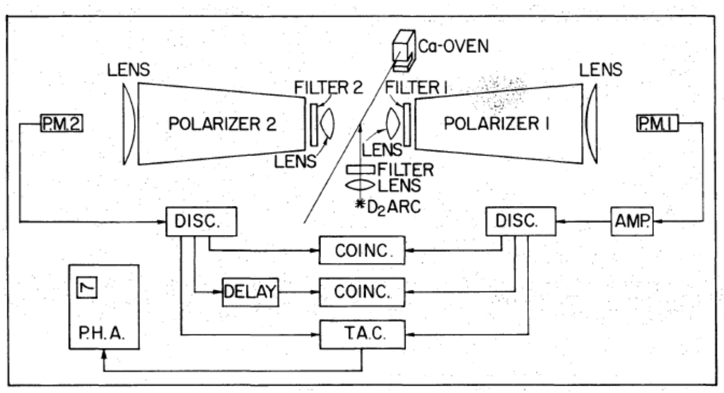

### 钙原子级联发出光子对

Ca-OVEN：钙光源；PM：探测器。

转动两侧偏振片（POLARIZER），COINC线路统计每秒的配对事件数，即符合率。

### 实验结果

违背适用于这套装置的Bell不等式，与量子预测一致。

探测漏洞：只测到部分光子，样本可能偏向某些结果。

局域性漏洞：方向固定，相关信息有时间传到另一站。

[Freedman与Clauser（1972）](https://doi.org/10.1103/PhysRevLett.28.938)；装置图：诺奖2022科学背景资料图4，据原实验转载。

## 1982年：在光子飞行中快速切换测量方向

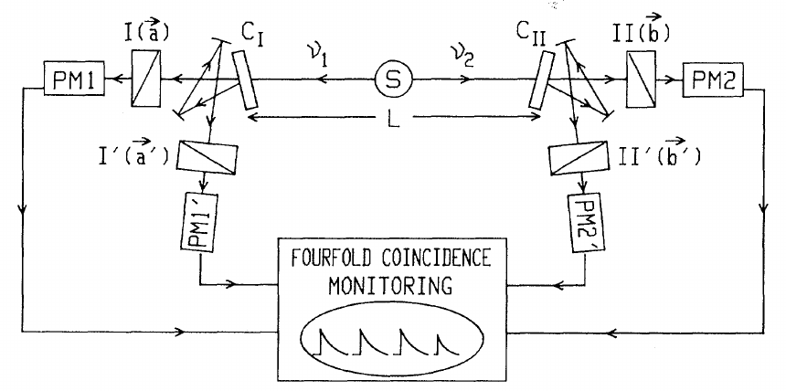

### 声光开关切换光路

S发出光子对；两侧开关C各把光子导向两个固定取向的偏振片之一，PM记录探测结果。

### 在信息到达前测量

切换时间短于两站间光速传播的时间，实验仍观察到Bell违背。

仍待改进：周期性切换可被提前预测；探测到的仍只是部分光子。

[Aspect、Dalibard、Roger（1982），原论文图2。](https://doi.org/10.1103/PhysRevLett.49.1804)

## 在另一站获知测量方向前完成探测

两站距离为$L$；从Alice选方向到Bob记结果的时间间隔为$\Delta t$。

$$\Delta t<L/c$$

这次选择的信息来不及以光速或更慢速度到达Bob；反方向也须满足这一条件。

再让两站各自随机选方向，减少对方提前预知选择的机会。

## 1998年：两站相隔400米，各自随机选方向

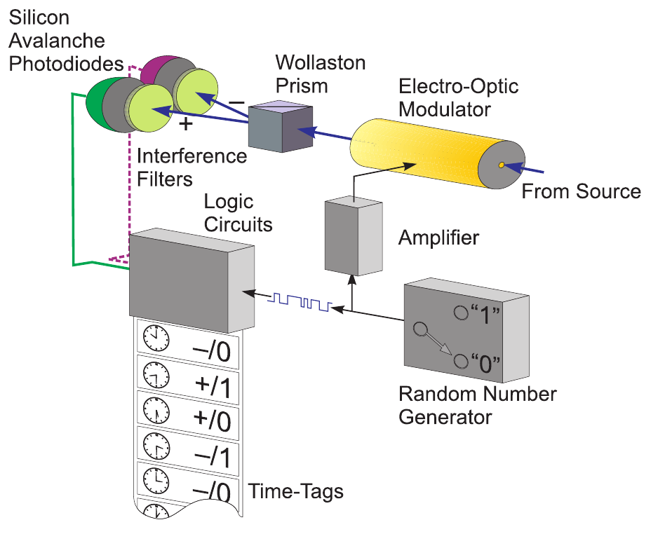

### 每站独立完成测量

随机数发生器产生0或1，控制电光调制器选择方向；两只探测器记录正、负结果。

Time-Tags保存时间、方向编号与结果；实验后合并两站记录。

### 实际记录给出的结果

$$S=2.73\pm0.02>2$$

更严格地满足局域性条件；仍需假定探测样本代表全部发射事件，探测漏洞尚在。

[Weihs等（1998），原论文图2；0.02为统计误差。原实验态与符号安排不同，经典界限同为2。](https://doi.org/10.1103/PhysRevLett.81.5039)

## 统计误差小，为什么还要查样本？

仍看$S=2.73\pm0.02$：误差给出有限记录的统计波动尺度，并非绝对上下限。

### 超界幅度与波动相比

$$2.73-2=0.73\gg0.02$$

这支持超界并非通常的统计波动。

### 留下的记录代表谁？

若漏探测偏向某些测量方向或结果，留下的配对记录就可能失真。

样本偏差不会因多测几轮自动消失。

误差说明统计可靠性；排除局域解释还须落实时序与采样条件。

[沿用Weihs等（1998）的实验报告；本页只作误差含义与量级比较。](https://doi.org/10.1103/PhysRevLett.81.5039)

## 2015年：随机选方向，并记录每轮有无响应

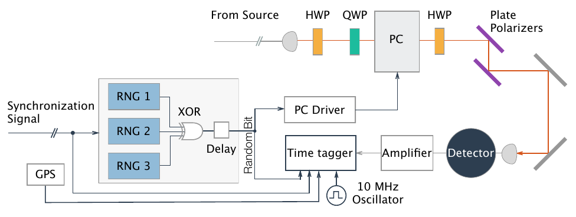

一个接收站：RNG产生随机0或1，PC（普克尔盒）据此选择测量方向；光子经过偏振片，由Detector探测。

两站用同步时钟划分轮次；Time tagger记录信号，按相同轮次编号合并记录。

[Shalm等（2015），作者公开稿图2。](https://doi.org/10.1103/PhysRevLett.115.250402)

## 每轮都记录探测器有无响应

2015年Shalm等监测一路偏振通道，按同步时钟划分轮次、编号记录。

| Alice / Bob | 有响应 | 无响应 |
| --- | --- | --- |
| 有响应 | 双方有响应 | 仅Alice有响应 |
| 无响应 | 仅Bob有响应 | 双方无响应 |

有响应：本轮记录到探测信号；无响应：本轮没有探测信号。

无响应包括损失、漏探测或光子未通过所测通道。

此前的双通道模型用两只探测器，分别记录+1、−1。

每轮有无响应都保留，再用相应的Bell不等式检验局域模型。

[Shalm等，Strong Loophole-Free Test of Local Realism，PRL 115，250402（2015），正文及表I。](https://doi.org/10.1103/PhysRevLett.115.250402)

## 2015年：同时关闭局域性与探测两类主要漏洞

Shalm等把随机选方向、时序与探测条件放进同一次检验：

### 随机选方向

快速随机选方向；评估另一站提前猜中方向的可能性。

### 空间与时间

两侧测量完成时，远方所选方向的信息都来不及到达。

### 探测与样本

提高探测效率；一侧有响应、两侧无响应的轮次也保留。

如果所检验的局域模型成立，出现至少这样强违背的概率不超过：

$$2.3\times10^{-7}$$

检验以测量选择与隐藏信息独立等为前提，并计入方向可能被提前预测的影响。

[Shalm等（2015），表I：五脉冲方案、计入测量方向可预测性后的统计检验结果。](https://doi.org/10.1103/PhysRevLett.115.250402)

## 2022年诺贝尔物理学奖

[figure not shown]

阿兰·阿斯佩

Alain Aspect

[figure not shown]

约翰·克劳泽

John F. Clauser

[figure not shown]

安东·蔡林格

Anton Zeilinger

### 授奖词

“for experiments with entangled photons, establishing the violation of Bell inequalities and pioneering quantum information science”

“表彰他们利用纠缠光子开展实验，证实贝尔不等式的违背，并开创量子信息科学。”

肖像：Niklas Elmehed © Nobel Prize Outreach；[官方教学幻灯片](https://www.nobelprize.org/uploads/2022/10/Slideshow_Physics_2022_NobelPrizeLessons.pdf)；[官方授奖辞](https://www.nobelprize.org/prizes/physics/2022/press-release/)（中文为译文）。

## 局域隐变量模型仍受答案卡上限约束

给定双方共享的全部隐藏信息，每人的结果概率只由自己的测量方向和这份信息决定；两人的剩余随机性独立。

### 把随机作答写成答案卡

再把各自用于随机作答的数固定，每个题号会答什么就确定了，得到一套答案卡。

让这些数随机变化，就得到固定答案卡的随机混合。

测量方向的选择还须与隐藏信息独立，因此这类模型必须满足Bell不等式。

实验检查时间安排与探测记录后仍见Bell违背，在这些前提下排除了这类局域模型。

## 纠缠关联不能用来超光速传信

Alice选$\alpha=0^\circ$表示发0，选$\alpha=45^\circ$表示发1；Bob固定$\beta$，尝试只凭自己的记录辨认消息。每轮用一对新光子制备同一Bell态：

$$|\Phi^+\rangle=\frac{|HH\rangle+|VV\rangle}{\sqrt2}$$

Alice的正、负结果各占一半，Bob合并这两类轮次：

$$P_B(+1)=\tfrac12\cos^2(\alpha-\beta)+\tfrac12\sin^2(\alpha-\beta)=\tfrac12$$

Alice选0°、45°或其他方向，Bob的正负结果都各半；重复多轮也无法据此分辨0或1。

看出纠缠关联需要普通通信交换测量方向与结果；这一步受光速限制。

## 实验怎样回应EPR的疑问

### EPR希望补上什么？

补充量子态尚未写出的信息，同时保持局域性。

### 实验检验局域隐变量解释

在测量方向独立选择等前提下，检查测量时间与样本后，实验仍见Bell违背。

### 完备性问题仍待讨论

量子态是否给出全部物理描述，还需进一步研究。

Bell违背排除了这类局域解释；量子态是否完备，仍是另一个问题。

## 课堂自查

思考

1. 同测Z结果总相同，为什么还不足以证明经典卡片失效？

2. 问题编号1，在经典策略和量子策略里分别选择什么？

3. 同一套方向，第二批模拟胜场更多，理论胜率提高了吗？

1. 共享相同随机数字已能给出完全关联，还要比较四种方向组合。

2. 经典读取预写答案；量子选择方向，再把测量结果换成答案。

3. 理论概率由方向决定；有限模拟战绩会波动。

## 来源与进一步阅读（1）

[EPR：实在性与完备性（1935）](https://doi.org/10.1103/PhysRev.47.777)

[Bohr：回应EPR（1935）](https://doi.org/10.1103/PhysRev.48.696)

[Bell：局域模型的关联限制（1964）](https://doi.org/10.1103/PhysicsPhysiqueFizika.1.195)

[CHSH：可实验检验的形式（1969）](https://doi.org/10.1103/PhysRevLett.23.880)

[Cirel’son：量子CHSH上限，Lett. Math. Phys. 4，93–100（1980）](https://doi.org/10.1007/BF00417500)

↑ 返回课堂自查

## 来源与进一步阅读（2）

[Freedman与Clauser：光子实验（1972）](https://doi.org/10.1103/PhysRevLett.28.938)

[Aspect等：快速切换实验（1982）](https://doi.org/10.1103/PhysRevLett.49.1804)

[Weihs等：严格局域性条件（1998）](https://doi.org/10.1103/PhysRevLett.81.5039)

[2022年诺贝尔物理学奖：官方介绍](https://www.nobelprize.org/prizes/physics/2022/popular-information/)

↑ 返回课堂自查

## 一键三连

[figure not shown]